# Snippets

part 2 of the Tips and Tricks Series

Jeremy Allen

Nov 2, 2021, updated on 2021-11-04

# Review

- shift+cmd+p for command palette
- shift+cmd+m for pipe
- alt-dash for assignment
- cmd+, for global options
- how do we fold code?

# Snippets! How do they work?

First, let’s prep some data

## Get data from the palmerpenguins package and inspect names

```r
df <- penguins_raw

df
```

```
## # A tibble: 344 × 17
##    studyName `Sample Number` Species       Region Island Stage   `Individual ID`
##    <chr>               <dbl> <chr>         <chr>  <chr>  <chr>   <chr>
##  1 PAL0708                 1 Adelie Pengu… Anvers Torge… Adult,… N1A1
##  2 PAL0708                 2 Adelie Pengu… Anvers Torge… Adult,… N1A2
##  3 PAL0708                 3 Adelie Pengu… Anvers Torge… Adult,… N2A1
##  4 PAL0708                 4 Adelie Pengu… Anvers Torge… Adult,… N2A2
##  5 PAL0708                 5 Adelie Pengu… Anvers Torge… Adult,… N3A1
##  6 PAL0708                 6 Adelie Pengu… Anvers Torge… Adult,… N3A2
##  7 PAL0708                 7 Adelie Pengu… Anvers Torge… Adult,… N4A1
##  8 PAL0708                 8 Adelie Pengu… Anvers Torge… Adult,… N4A2
##  9 PAL0708                 9 Adelie Pengu… Anvers Torge… Adult,… N5A1
## 10 PAL0708                10 Adelie Pengu… Anvers Torge… Adult,… N5A2
## # … with 334 more rows, and 10 more variables: Clutch Completion <chr>,
## #   Date Egg <date>, Culmen Length (mm) <dbl>, Culmen Depth (mm) <dbl>,
## #   Flipper Length (mm) <dbl>, Body Mass (g) <dbl>, Sex <chr>,
## #   Delta 15 N (o/oo) <dbl>, Delta 13 C (o/oo) <dbl>, Comments <chr>
```

```r
# gross!
names(df)
```

```
##  [1] "studyName"           "Sample Number"       "Species"
##  [4] "Region"              "Island"              "Stage"
##  [7] "Individual ID"       "Clutch Completion"   "Date Egg"
## [10] "Culmen Length (mm)"  "Culmen Depth (mm)"   "Flipper Length (mm)"
## [13] "Body Mass (g)"       "Sex"                 "Delta 15 N (o/oo)"
## [16] "Delta 13 C (o/oo)"   "Comments"
```

```r
# clean those names
df %>%
  clean_names() %>%
  names()
```

```
##  [1] "study_name"        "sample_number"     "species"
##  [4] "region"            "island"            "stage"
##  [7] "individual_id"     "clutch_completion" "date_egg"
## [10] "culmen_length_mm"  "culmen_depth_mm"   "flipper_length_mm"
## [13] "body_mass_g"       "sex"               "delta_15_n_o_oo"
## [16] "delta_13_c_o_oo"   "comments"
```

## How about those column names?

A little regex first  
Pro tip: match anything that you put in []

```r
# are there spaces or capital letters in col names?
str_detect(names(df), "[\\sA-Z()/-]")
```

```
##  [1] TRUE TRUE TRUE TRUE TRUE TRUE TRUE TRUE TRUE TRUE TRUE TRUE TRUE TRUE TRUE
## [16] TRUE TRUE
```

```r
# but we only want one answer, so wrap in any()
any(str_detect(names(df), "[\\sA-Z()/-]"))
```

```
## [1] TRUE
```

Pro tip: str_view() to see string matches (requires htmlwidgets)

```r
# let's see where our pattern matches
str_view_all(names(df), "[\\sA-Z()/-]")
```

[interactive chart not shown]

# Finally, a snippet!

Pro tip: cmd+i to fix bad indentation

```r
# snippet time! type "if" then hit shift+tab
# paste in our regex condition and our clean_names code

if (any(str_detect(names(df), "[\\sA-Z()/-]"))) {
  df <- df %>%
    clean_names()
}

# highlight the if statement above then hit cmd+i to fix the indentation

# inspect
names(df)
```

```
##  [1] "study_name"        "sample_number"     "species"
##  [4] "region"            "island"            "stage"
##  [7] "individual_id"     "clutch_completion" "date_egg"
## [10] "culmen_length_mm"  "culmen_depth_mm"   "flipper_length_mm"
## [13] "body_mass_g"       "sex"               "delta_15_n_o_oo"
## [16] "delta_13_c_o_oo"   "comments"
```

## What will this return now? Someone tell me before running it!

```r
any(str_detect(names(df), "[\\sA-Z()/-]"))
```

```
## [1] FALSE
```

## Can we pipe that? Yes we can.

Pro tip: cmd+shift+m to insert pipe

```r
names(df) %>%
  str_detect("[\\sA-Z()/-]") %>%
  any()
```

```
## [1] FALSE
```

## Assign the clean names

Pro tip: alt+dash for assignment arrow

```r
df <- df %>%
  clean_names()
```

## More snippets! Functions

Pro tip: type fun then hit shift+tab  
Pro tip: cmd+f for find (and replace)

```r
# type fun then hit shift+tab
# name it clean_if_bad_names
# one arg called x
# put our if statement in the body
# cmd+i to fix indent
# cmd+f to change df to x

clean_if_bad_names <- function(x) {
  if (any(str_detect(names(x), "[\\sA-Z()/-]"))) {
    clean_names(x)
  }
  x
}

# reset df
df <- penguins_raw

clean_if_bad_names(x = df)
```

[output not shown]

## More snippets! For loops

```r
# type for then hit shift+tab
```

## More snippets! See them all

Pro tip: make your own

[figure not shown]

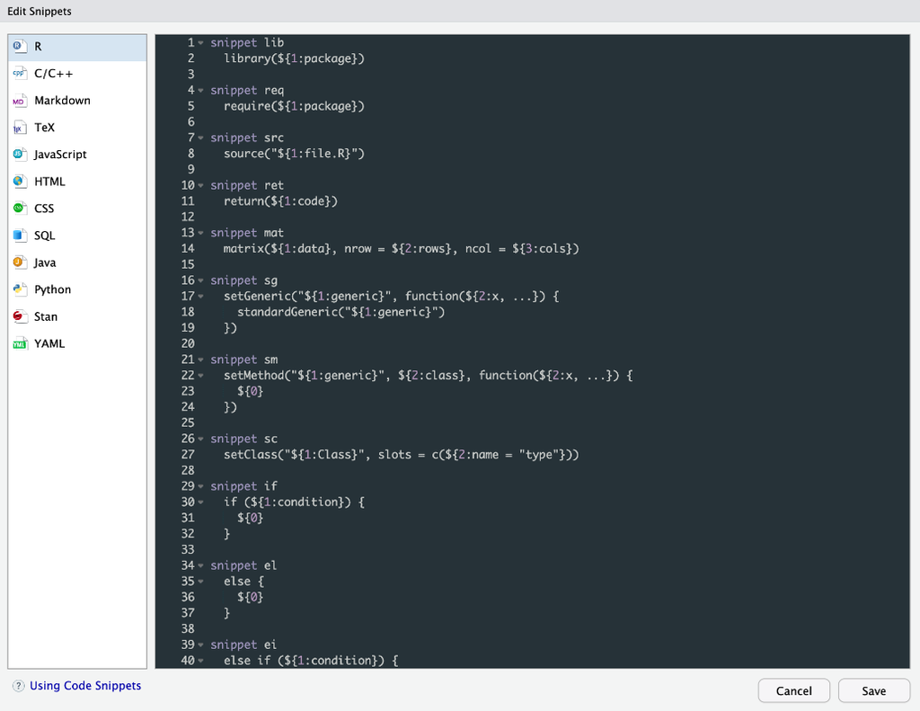

**Everyday Carry** - hit shift+tab after the ec

```r
ec
```

I use that as lightweight version of library(tidyverse) when I don’t want or need to load the entire tidyverse - particular important for a production environment that needs to be trim.

## ggplot2 GUI plot builder

from the package esquisse

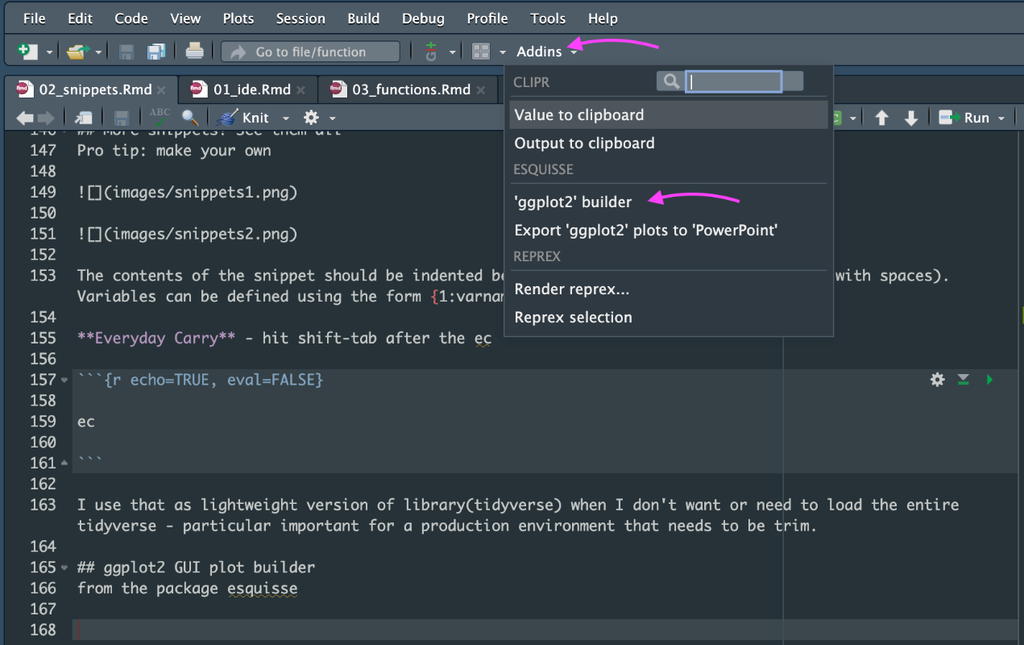

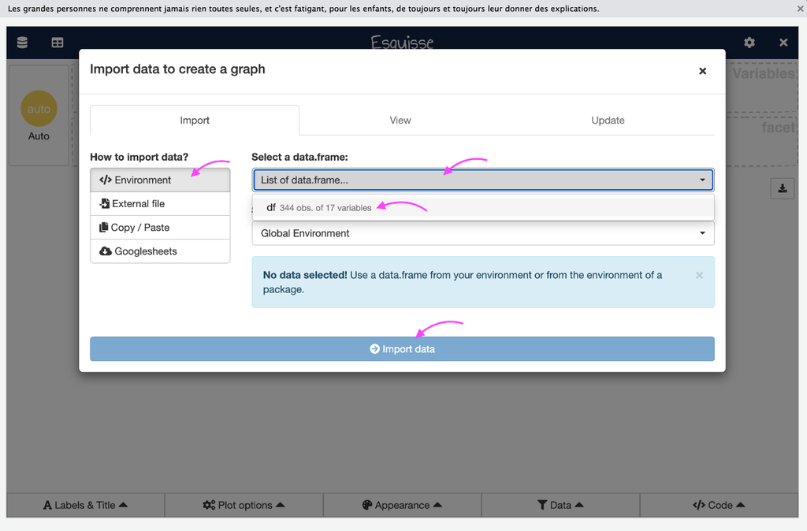

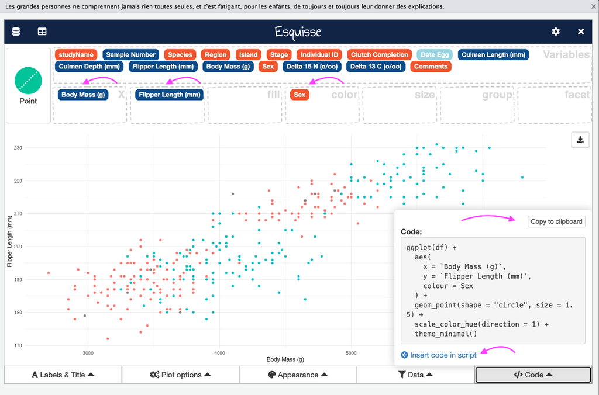